# hsR Session 4

Data Management II & Visualization for Exploratory Data Analysis

Nate Apathy

2.23.2018

# Review of Last Week’s Activities

Each of you had a section to do something with the un_hix1418 dataset we created

- Some things that may come in handy:
  - A few of these will require the data dictionary as a reference
  - Keep in mind that subsetting by column number is much easier when fields have unweildy names and there are lots of them
  - You’ll only need the first 19 columns for all the steps below
  - colnames() can help identify the number of the column you are trying to find
  - the syntax for subsetting is dataframename[rows,columns]
  - table() can help with cross-tabs/counts of variable pairs
  - length() counts how many elements are in a given object
  - skim(dataframename) can be very useful. try it! no need to create an object, just look at it in the Console output
  - you can subset within other functions without changing the object you are subsetting (if you don’t overwrite it)
  - example: length(dataframename[dataframename$column1==1 & dataframename$column2==4,])
  - will count the number of observations that match your criteria (like filtering in excel)

## Subsetting & Exploring Data

```r
load(file="un_hix1418.Rdata")
```

1. Subset the data frame down to the 2016 plans from two states of your choice (create a new data frame object)

```r
alnm16 <- un_hix1418[(un_hix1418$ST=="AL" | un_hix1418$ST=="NM") & un_hix1418$YEAR=="2016",]

alnm16d <- un_hix1418 %>% filter(ST %in% c("AL","NM") & YEAR==2016)
```

2. How many plans are in each of the metallic tiers for each state?

```r
table(alnm16$METAL,alnm16$ST)
```

```
##
##                 AL  NM
##   Bronze       136  42
##   Catastrophic  58  15
##   Gold          71  42
##   Platinum       6   5
##   Silver       175  47
```

3. Which area (from the state first in alphabetical order) had the most silver plan options in 2016?

```r
table(alnm16[alnm16$ST=="AL" & alnm16$METAL=="Silver",]$AREA,alnm16[alnm16$ST=="AL" & alnm16$METAL=="Silver",]$ST)
```

```
##
##        AL
##   AL01 13
##   AL02 13
##   AL03 15
##   AL04 13
##   AL05 15
##   AL06 13
##   AL07 13
##   AL08 13
##   AL09 15
##   AL10 13
##   AL11 13
##   AL12 13
##   AL13 13
```

4. Which state had the higher average premium for a 50-year-old purchasing a silver plan? What was that amount?

```r
mean(alnm16[alnm16$ST=="AL" & alnm16$METAL=="Silver",]$PREMI50)
```

```
## [1] 465.9641
```

```r
mean(alnm16[alnm16$ST=="NM" & alnm16$METAL=="Silver",]$PREMI50)
```

```
## [1] 374.0723
```

5. What was the most common plan type in area 3 of the second state?

```r
table(alnm16[alnm16$ST=="NM",]$PLANTYPE,alnm16[alnm16$ST=="NM",]$AREA)
```

```
##
##     NM01 NM02 NM03 NM04 NM05
##   1    1    1    1    1    1
##   2   28   28   28   31   31
```

```r
# type 2, which is HMO (from data dictionary)
```

6. Among HMO plans, what is the average premium for a 27-year-old?

```r
mean(alnm16[alnm16$PLANTYPE=="2",]$PREMI27)
```

```
## [1] 224.4668
```

# Visualizing Data Missingness

```r
table(un_hix1418$ST,un_hix1418$YEAR)
```

```
##
##      2014 2015 2016 2017 2018
##   AK   84  165   78   15   15
##   AL  101  757  446  130  138
##   AR  125  448  392  228  165
##   AZ  485  822  342   47   47
##   CA    0 1249 1247 1273 1014
##   CO    0  951 1009  657  611
##   CT    0  781  840  480  240
##   DC    0    5   24   20   26
##   DE   19   63   52   42    7
##   FL 2043 6254 5368 4520 2614
##   GA  383 2118 1740  866  292
##   HI    0   19   28   26   25
##   IA  267  564  689  406   84
##   ID  171  344  328  159  380
##   IL  601 1557  961  385  315
##   IN  376 1712 1395  958  242
##   KS  153  482  475  176   95
##   KY    0  429  460  218   97
##   LA  310  826  441  154  187
##   MA    0 1907 1392 1507  577
##   MD    0  287  167  156  134
##   ME   68  210  255  189   82
##   MI  664 2116 1540 1342  802
##   MN    0 1054  848  583  366
##   MO  172  732  630  190  183
##   MS   64  382  256  129  102
##   MT  116  228  144  102   86
##   NC  334 1185  842  213  164
##   ND  108  197  120  106   88
##   NE  145  324  224   87   42
##   NH    9   73   69   62   32
##   NJ  158  455  547  255  155
##   NM  197  306  151  187  162
##   NV    0  465  508  416   16
##   NY    0 1160 1173 1046  793
##   OH  651 2036 1655  951  602
##   OK  209  315  197  105   47
##   OR    0  821  575  321  188
##   PA  420  911  586  323  213
##   RI    0   33   47   28   23
##   SC 1312 3853 3310 2268 1104
##   SD  128  258  180   64   84
##   TN  392 1117  954  142   44
##   TX  831 2309 1511  743  520
##   UT  237  715  453  242  183
##   VA  321 1071 1114  884  253
##   VT    0   15   22   23   31
##   WA    0  388  487  311  166
##   WI 1190 2379 1715 1426 1091
##   WV  121  539  346  173  162
##   WY   36  153   96   93   30
```

```r
hixsamp <- filter(un_hix1418, YEAR %in% c("2016","2017") & ST %in% c("CA","MA")) %>%
  select(1:19,90:103)
colnames(hixsamp)[20:33]
```

```
##  [1] "ER_CopayInn_TIERS" "ER_CopayInnTier1"  "ER_CopayInnTier1A"
##  [4] "ER_CopayInnTier2"  "ER_CopayInnTier2A" "ER_CoinsInn_TIERS"
##  [7] "ER_CoinsInnTier1"  "ER_CoinsInnTier1A" "ER_CoinsInnTier2"
## [10] "ER_CoinsInnTier2A" "ER_CopayOutofNet"  "ER_CopayOutofNetA"
## [13] "ER_CoinsOutofNet"  "ER_CoinsOutofNetA"
```

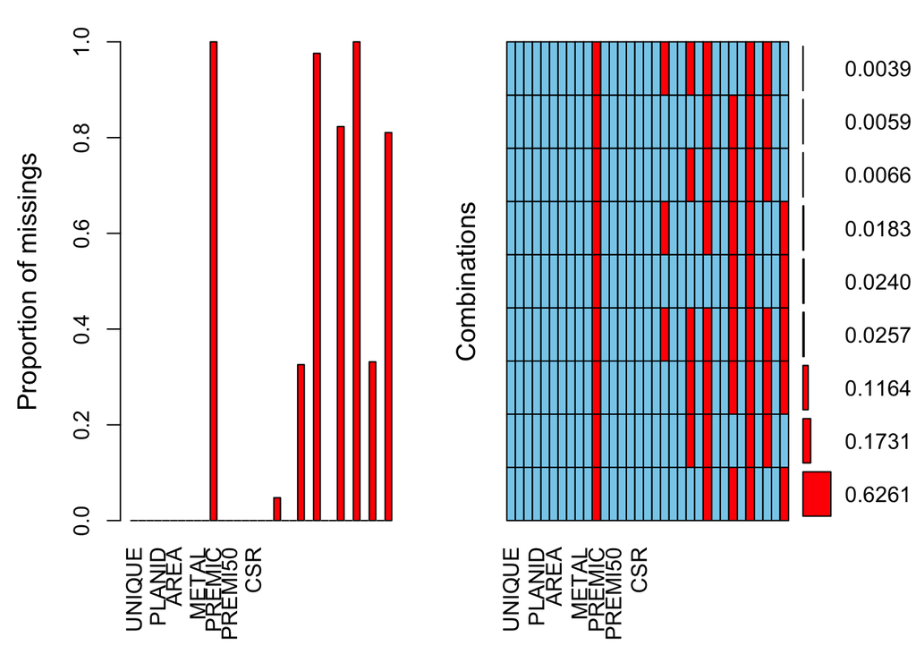

```r
aggr(hixsamp, prop = T, numbers=TRUE)
```

```r
skim(hixsamp)
```

|  | variable | type | stat | level | value | formatted |
| --- | --- | --- | --- | --- | --- | --- |
| 1 | UNIQUE | integer | missing | .all | 0.000000e+00 | 0 |
| 2 | UNIQUE | integer | complete | .all | 5.419000e+03 | 5419 |
| 3 | UNIQUE | integer | n | .all | 5.419000e+03 | 5419 |
| 4 | UNIQUE | integer | mean | .all | 8.850864e+04 | 88508.64 |
| 5 | UNIQUE | integer | sd | .all | 1.879106e+04 | 18791.06 |
| 6 | UNIQUE | integer | p0 | .all | 6.180000e+04 | 61800 |
| 7 | UNIQUE | integer | p25 | .all | 7.696450e+04 | 76964.5 |
| 8 | UNIQUE | integer | median | .all | 9.946100e+04 | 99461 |
| 9 | UNIQUE | integer | p75 | .all | 1.098825e+05 | 109882.5 |
| 10 | UNIQUE | integer | p100 | .all | 1.112370e+05 | 111237 |

[output cut: 309 more lines]

```r
unique(hixsamp$CARRIER)
```

```
##  [1] "Kaiser Permanente"
##  [2] "L.A. Care Health Plan"
##  [3] "Molina"
##  [4] "Oscar"
##  [5] "Sharp Health Plan"
##  [6] "UnitedHealthcare"
##  [7] "Western Health Advantage"
##  [8] "Anthem"
##  [9] "BlueShield of California"
## [10] "Ambetter"
## [11] "Health Net"
## [12] "Cigna"
## [13] "Chinese Community Health Plan"
## [14] "Sutter Health Plan"
## [15] "Valley Health Plan"
## [16] "BlueCross BlueShield of Massachusetts"
## [17] "Tufts Health Plan"
## [18] "Harvard Pilgrim"
## [19] "HNE"
## [20] "Neighborhood Health Plan"
## [21] "Minuteman Health"
## [22] "ConnectiCare"
## [23] "Fallon Health"
## [24] "BMC HealthNet"
```

```r
table(hixsamp$ER_CoinsInnTier1A,useNA = "always")
```

```
##
##   10   15   20   30   35   40   50  100 <NA>
##   14   57   65  193  121  237   10  262 4460
```

# Visualization of Data Summaries with the Tidyverse

```r
avg_prem_example <- un_hix1418 %>% group_by(YEAR, ST, METAL) %>%
  summarize(avg_27_prem = mean(PREMI27),
            avg_50_prem = mean(PREMI50),
            avg_fam4_prem = mean(PREMC2C30)) %>%
  mutate(avg_prem = (avg_27_prem + avg_50_prem + avg_fam4_prem)/3,
         METAL = factor(METAL,levels = c("Catastrophic","Bronze","Silver","Gold","Platinum")))

avg_prem_example
```

| YEAR | ST | METAL | avg_27_prem | avg_50_prem | avg_fam4_prem | avg_prem |
| --- | --- | --- | --- | --- | --- | --- |
| 2014 | AK | Bronze | 303.9000 | 517.8333 | 1026.6000 | 616.1111 |
| 2014 | AK | Catastrophic | 236.0000 | 402.0000 | 798.0000 | 478.6667 |
| 2014 | AK | Gold | 416.5714 | 709.7619 | 1406.8571 | 844.3968 |
| 2014 | AK | Silver | 364.8000 | 621.6667 | 1232.3333 | 739.6000 |
| 2014 | AL | Bronze | 164.6673 | 280.6253 | 556.2227 | 333.8384 |
| 2014 | AL | Catastrophic | 139.8533 | 238.3373 | 472.4027 | 283.5311 |
| 2014 | AL | Gold | 258.6779 | 440.8396 | 873.7786 | 524.4320 |
| 2014 | AL | Platinum | 306.3467 | 522.0760 | 1034.7880 | 621.0702 |
| 2014 | AL | Silver | 206.7050 | 352.2682 | 698.2271 | 419.0668 |
| 2014 | AR | Bronze | 202.0141 | 344.2727 | 682.3818 | 409.5562 |

[output cut: 1093 more lines]

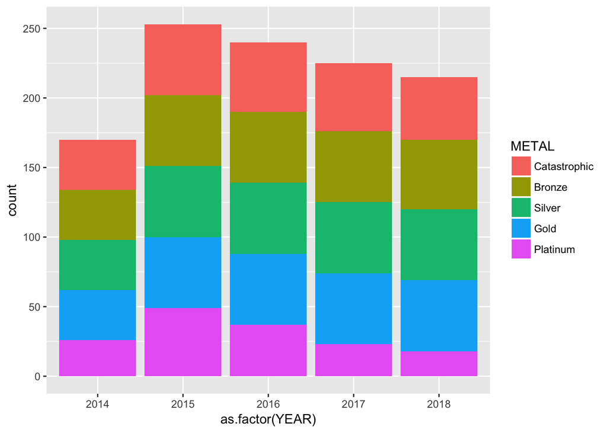

```r
ggplot(avg_prem_example, aes(x=as.factor(YEAR))) + geom_bar(aes(fill=METAL))
```

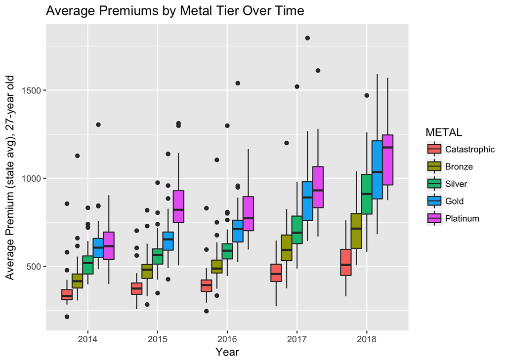

```r
ggplot(avg_prem_example, aes(x=as.factor(YEAR),y=avg_prem)) + geom_boxplot(aes(fill=METAL)) +
  labs(x="Year", y="Average Premium (state avg), 27-year old",
       title="Average Premiums by Metal Tier Over Time")
```

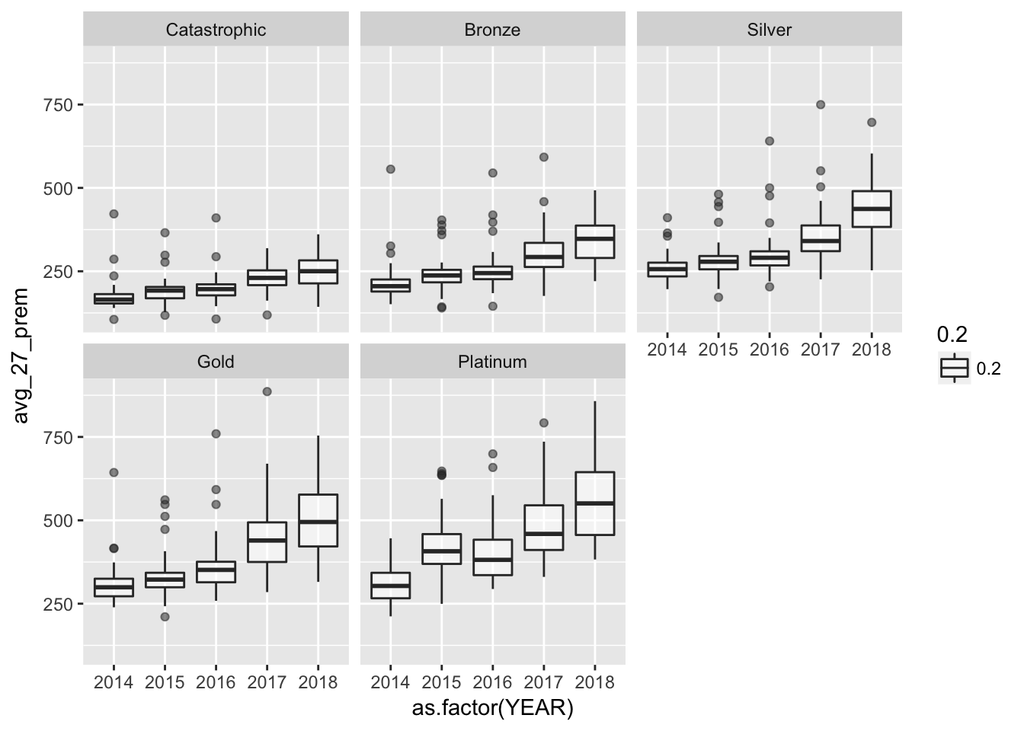

```r
ggplot(avg_prem_example, aes(x=as.factor(YEAR))) +
  geom_boxplot(aes(alpha=0.2,y=avg_27_prem)) +
  facet_wrap(~METAL)
```

# Class Exercise: Summarizing Data by State and Year

Question: On average, how many plans of each metallic tier were offered in each area of each state over the years?